# File S9: Contamination Analysis

Eric S. Tvedte

November 4, 2019

# Usage

Assessment of contamination was assessed by mapping reads from Riptide to a reference sequence containing all genomes used in the experiment.

Unix commands are given in blue.

# Input dataset

This analysis requires a single reference FASTA containing all genomes files

# Mapped read counts

### 1. bwa mem

bwa mem -k 23 -M reference.fasta R1.fastq.gz R2.fastq.gz | samtools view -bho mapped.bam

### 2. Sort BAM using SAMtools

samtools sort -m 2G -o sorted.bam mapped.bam

### 3. Mark duplicate reads using Picard Tools

java -Xmx2g -jar picard.jar MarkDuplicates I=sorted.bam O=dupsmarked.bam M=dupsmetrics.txt

### 4. Parse readsets using SAMtools

### 5. Filter 1: Species assignment using primary reads

samtools view -h -F 4 -F 256 -F 1024 -F 2048 dupsmarked.bam | samtools view -bh - > filter_unmap+dups.bam

samtools view filter_unmap+dups.bam | awk -F “” ‘{print $3}’ | sort -n | sed “s/_scaf.*//g" | uniq -c | awk ‘{print $2“”$1}’ > speciesmap.txt

### 6. Load data

Species assignment files were compiled, with an additional row added containing numbers corresponding to the position of each sample on the Riptide plate

```r
in.path = "Y:/RDRIP/etvedte/Contamination/Filter1/final_species_map_compiled.txt"
file <- read.table(in.path, header = F, sep = '\t')

file[is.na(file)] <- 0

#reorder file based on well number
x <- file[order(file[12,])]
#remove well number from file
x <- x[-c(12), ]

#write out reordered file as sanity check
write.table(x, file = "Y:/RDRIP/etvedte/Contamination/Filter1/reordered_species_map_compiled.txt", sep = '\t', col.names = FALSE, row.names = FALSE, quote = FALSE)

new.file <- read.table("Y:/RDRIP/etvedte/Contamination/Filter1/reordered_species_map_compiled.txt", header = T, sep = '\t')

new.file[is.na(new.file)] <- 0
```

### 7. Generate legend for Riptide samples

```r
#optional pdf output
#pdf("Y:/RDRIP/etvedte/Contamination/Filter1/RIPTIDE_Filter1_speciesmap_legend.pdf")

  #make legend
  rip.col <- c('#e6194b', '#3cb44b', '#ffe119', '#4363d8', '#f58231', '#911eb4', '#46f0f0','#f032e6', '#bcf60c', '#fabebe')
  plot(NULL ,xaxt='n',yaxt='n',bty='n',ylab='',xlab='', xlim=0:1, ylim=0:1)
  legend(x = "center", y = NULL, legend = paste(new.file[,1]), text.col = rip.col)
```

[output not shown]

```r
#optional pdf close
#dev.off()
```

### 8. Generate pie charts for Riptide plate wells

```r
#optional pdf output
#pdf("Y:/RDRIP/etvedte/Contamination/Filter1/RIPTIDE_Filter1_speciesmap_wells_new.pdf", height = 6, width = 6)

  #set up grid for visualization
  par(mfrow = c(12,12))
  par(mar = c(0.25,0.25,0.25,0.25))

  #set maxmap variables
  count90 = 0
  count95 = 0
  count99 = 0

  #iterate over each well
  for (i in 2:97){
    new.file[,1] <- as.character(new.file[,1])

    new.file[,i] <- (new.file[,i] / sum(new.file[,i]) * 100)

    new.file[,i] <- round(new.file[,i], 2)

    slices <- new.file[,i]
    #lbls <- new.file[,1]
    pct <- round(slices/sum(slices)*100)
    pie(new.file[,i], labels = NA, col=rip.col, radius = 1)
    #title(main = toString(colnames(new.file[i])), cex.main = 0.5)

    #count wells with maxmap criteria
    if (max(new.file[,i] > 90)){
      count90 = count90 + 1
    }
    if (max(new.file[,i] > 95)){
      count95 = count95 + 1
    }
    if (max(new.file[,i] > 99)){
      count99 = count99 + 1
    }
  }
#optional pdf close
#dev.off()

#par(new = TRUE)
#legend(x = "bottom", y = NULL, legend = paste(file[,1]), text.col = rip.col)

print(paste("Number of samples with 90% reads mapping a single species =", count90, sep = " "))
```

```
## [1] "Number of samples with 90% reads mapping a single species = 64"
```

```r
print(paste("Number of samples with 95% reads mapping a single species =", count95, sep = " "))
```

```
## [1] "Number of samples with 95% reads mapping a single species = 51"
```

```
## [1] "Number of samples with 99% reads mapping a single species = 1"
```

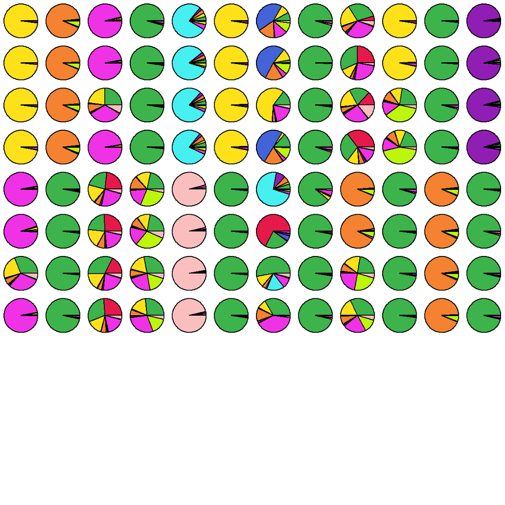

```r
print(paste("Number of samples with 99% reads mapping a single species =", count99, sep = " "))
```

### 9. Species assignment using primary, non-multimapping reads

samtools view -h -F 4 -F 256 -F 1024 -F 2048 dupsmarked.bam | grep -v -e ‘XA:Z:’ -e ‘SA:Z:’ | samtools view -bh - > filter_multimap.bam

samtools view filter_multimap.bam | awk -F “” ‘{print $3}’ | sort -n | sed “s/_scaf.*//g" | uniq -c | awk ‘{print $2“”$1}’ > speciesmap.txt

```
## [1] "Number of samples with 90% reads mapping a single species = 63"
```

```
## [1] "Number of samples with 95% reads mapping a single species = 55"
```

```
## [1] "Number of samples with 99% reads mapping a single species = 6"
```

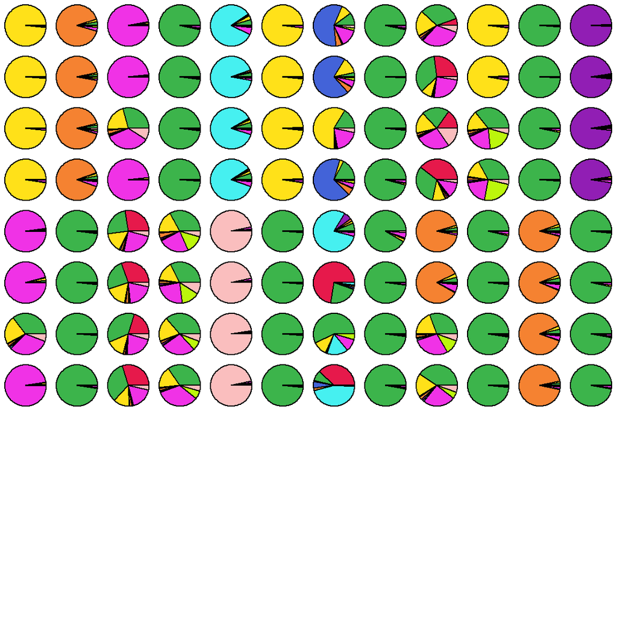

### 10. Species assignment using primary, MAPQ > 30 reads

samtools view -h -F 4 -F 256 -F 1024 -F 2048 -q 30 dupsmarked.bam | samtools view -bh - > filter_lowMAPQ.bam

samtools view filter_lowMAPQ.bam | awk -F “” ‘{print $3}’ | sort -n | sed “s/_scaf.*//g" | uniq -c | awk ‘{print $2“”$1}’ > speciesmap.txt

```
## [1] "Number of samples with 90% reads mapping a single species = 67"
```

```
## [1] "Number of samples with 95% reads mapping a single species = 63"
```

```
## [1] "Number of samples with 99% reads mapping a single species = 5"
```

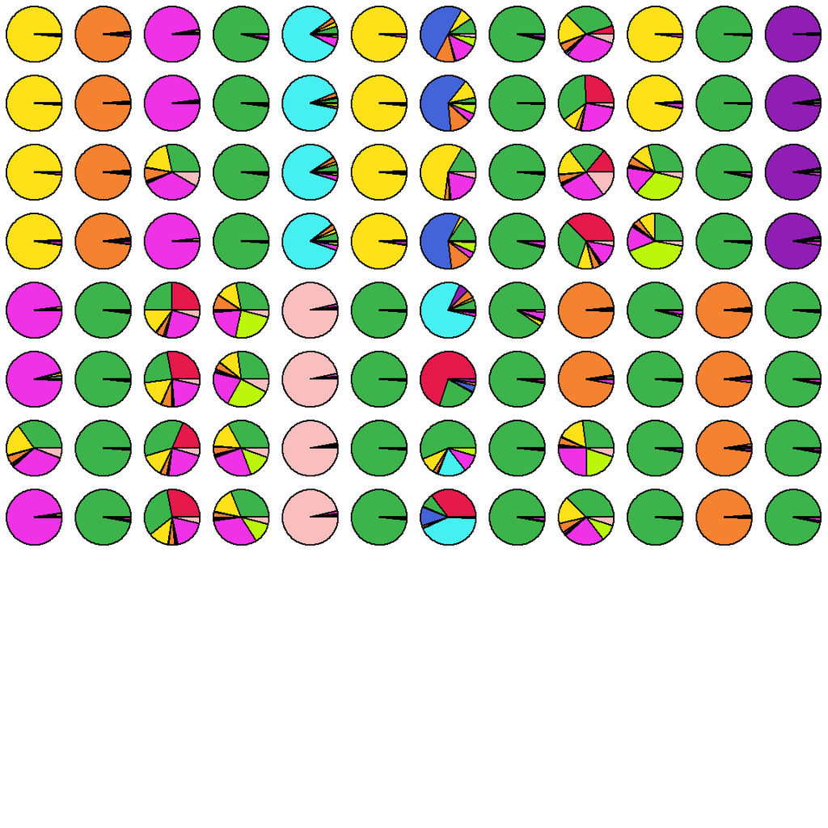

Document processed on: 2019-11-05 .